# Introduction to Malaria Modeling Skills in R & RStudio using ML Algorithms

# TRAIN OR BUILD MACHINE LEARNING MODELS

The model is trained until it can detect the underlying patterns and relationships, enabling it to yield good results when presented with unseen data.

# Train a Support Vector Machine (SVM) model

# Support Vector Machine (SVM)

SVM is a supervised machine learning algorithm used for classification and regression tasks. The primary goal of SVM is to find a hyperplane that best divides a dataset into classes.

# Types of Support Vector Machine

# Linear SVM

Used when data is linearly separable. It finds a straight hyperplane that separates the data into classes.

# Non-linear SVM

Used when data is not linearly separable. It employs kernel functions to map data into higher dimensions to find a hyperplane.

# Applications of SVM

= Text classification = Healthcare (e.g., malaria diagnosis, patient risk assessment)

#preProcess = c(“scale”, “center”) Ensure that the input features are standardized (mean = 0, standard deviation = 1), which is essential for models that are sensitive to the scale of input variable

# Train a Support Vector Machine (SVM) model

```r
tuneGrid_svm <- expand.grid(C = c(0.1, 1, 10, 100),sigma = c(0.01, 0.1, 1))
```

```r
set.seed(123)
tic()
SvmModel <- train(factor(Malaria.Test)~.,
                  data=train,
                  method="svmRadial",
                  preProcess= c("scale", "center"),
                  trControl=control,
                  tuneGrid=tuneGrid_svm,
                  na.action = na.omit)
toc()
```

```
591 sec elapsed
```

```r
SvmModel
```

```
Support Vector Machines with Radial Basis Function Kernel

2293 samples
  12 predictor
   2 classes: 'Negative', 'Positive'

Pre-processing: scaled (12), centered (12)
Resampling: Cross-Validated (10 fold, repeated 5 times)
Summary of sample sizes: 2064, 2063, 2064, 2064, 2064, 2063, ...
Addtional sampling using SMOTE prior to pre-processing

Resampling results across tuning parameters:

  C      sigma  Accuracy   Kappa
    0.1  0.01   0.9358859  0.5133620
    0.1  0.10   0.9458328  0.5484916
    0.1  1.00   0.9649420  0.4472883
    1.0  0.01   0.9405949  0.5309453
    1.0  0.10   0.9631957  0.6160005
    1.0  1.00   0.9605824  0.3950018
   10.0  0.01   0.9542145  0.5925927
   10.0  0.10   0.9655526  0.5931978
   10.0  1.00   0.9609329  0.3842207
  100.0  0.01   0.9624150  0.6061444
  100.0  0.10   0.9618040  0.5131932
  100.0  1.00   0.9610195  0.3837921

Accuracy was used to select the optimal model using the largest value.
The final values used for the model were sigma = 0.1 and C = 10.
```

```r
SvmModel$results
```

```
       C sigma  Accuracy     Kappa  AccuracySD    KappaSD
1    0.1  0.01 0.9358859 0.5133620 0.012502335 0.06865509
4    1.0  0.01 0.9405949 0.5309453 0.012379157 0.06601899
7   10.0  0.01 0.9542145 0.5925927 0.010598911 0.06798877
10 100.0  0.01 0.9624150 0.6061444 0.009656753 0.09829993
2    0.1  0.10 0.9458328 0.5484916 0.011270831 0.06784881
5    1.0  0.10 0.9631957 0.6160005 0.009482259 0.09228907
8   10.0  0.10 0.9655526 0.5931978 0.008201209 0.10478239
11 100.0  0.10 0.9618040 0.5131932 0.010527074 0.15074489
3    0.1  1.00 0.9649420 0.4472883 0.009748662 0.16951116
6    1.0  1.00 0.9605824 0.3950018 0.010173033 0.16063656
9   10.0  1.00 0.9609329 0.3842207 0.009198550 0.15676754
12 100.0  1.00 0.9610195 0.3837921 0.008967255 0.15306119
```

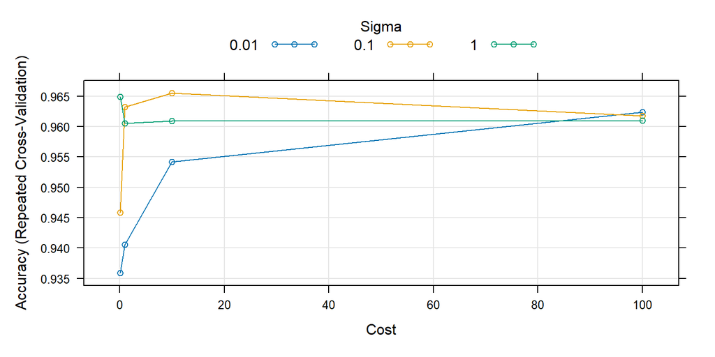

```r
plot(SvmModel)
```

# C:

This parameter is known as the regularization parameter in SVM

This parameter plays a crucial role in determining the trade-off between achieving a low error on the training data and minimizing the model’s complexity, which helps in preventing overfitting.

A smaller C value allows the model to have a smoother decision boundary by permitting some misclassifications on the training data. This can be useful for datasets with noise or outliers.

# sigma (γ):

This parameter controls the spread of the Gaussian function in the RBF kernel. A lower sigma value corresponds to a wider Gaussian function, which essentially considers data points farther away during the decision boundary formation. This can be helpful for capturing smoother, less complex non-linear relationships between data points

```r
# Make prediction on test dataset using Trained SVM Model
Svmpred= predict(SvmModel,newdata = test)

# Evaluate SVM model performance metrics
SVM_CM<- confusionMatrix(Svmpred, as.factor(test$Malaria.Test), positive = "Positive", mode="everything")
M1 <- SVM_CM$byClass[c(1, 2, 5, 7, 11)]
M1
```

```
      Sensitivity       Specificity         Precision                F1
        0.7837838         0.9726316         0.5272727         0.6304348
Balanced Accuracy
        0.8782077
```

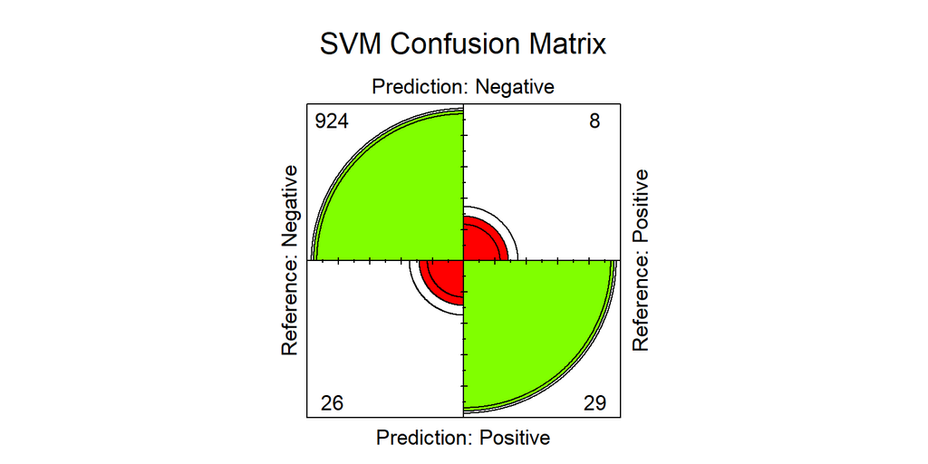

```r
#RF Confusion Matrix 4fold plot
fourfoldplot(SVM_CM$table, col=rainbow(4), main="SVM Confusion Matrix")
```

# Prediction using Trained SVM Model

```r
Svmpred= predict(SvmModel,newdata = test)

# Combine data into a data frame
Ground_truth<- test$Malaria.Test
Predicted <- Svmpred

resultSvm <- data.frame(Ground_truth, Predicted)
resultSvm$Correct <- resultSvm$Ground_truth == resultSvm$Predicted

# Add a column for classification results (correct/incorrect)
resultSVM<- data.frame(test, Svmpred, resultSvm$Correct)
print(resultSvm,15)
```

```
    Ground_truth Predicted Correct
1       Negative  Negative    TRUE
2       Negative  Negative    TRUE
3       Negative  Negative    TRUE
4       Negative  Negative    TRUE
5       Negative  Negative    TRUE
6       Negative  Negative    TRUE
7       Negative  Positive   FALSE
8       Negative  Negative    TRUE
9       Negative  Negative    TRUE
10      Negative  Negative    TRUE
11      Negative  Negative    TRUE
12      Negative  Negative    TRUE
13      Positive  Positive    TRUE
14      Negative  Negative    TRUE
```

[output cut: 973 more lines]

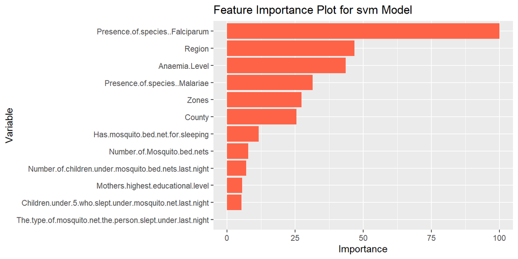

```r
# Alternatively using ggplot function
var_imp <-varImp(SvmModel)
ggplot(var_imp, aes(x = reorder(Variable, Importance), y = importance)) +
  geom_bar(stat = "identity", fill = "tomato") +
  coord_flip() +
  xlab("Variable") +
  ylab("Importance") +
  ggtitle("Feature Importance Plot for svm Model")
```

# Train a Random Forest model

# Random Forests

This is an ensemble learning method that combines multiple decision trees to improve prediction accuracy and reduce variance. # mtry This parameter controls the number of features randomly chosen as candidates for splitting a node in each tree.

```r
tuneGrid_rf <- expand.grid(mtry = c(2, 4, 6, 8, 12))
```

```r
set.seed(123)
tic()
RFModel <- train(factor(Malaria.Test)~.,
                 data=train,
                 method="rf",
                 trControl=control,
                 tuneGrid=tuneGrid_rf,
                 na.action = na.omit)
toc()
```

```
591.34 sec elapsed
```

```r
RFModel
```

```
Random Forest

2293 samples
  12 predictor
   2 classes: 'Negative', 'Positive'

No pre-processing
Resampling: Cross-Validated (10 fold, repeated 5 times)
Summary of sample sizes: 2064, 2063, 2064, 2064, 2064, 2063, ...
Addtional sampling using SMOTE

Resampling results across tuning parameters:

  mtry  Accuracy   Kappa
   2    0.9760182  0.6984215
   4    0.9738401  0.6671540
   6    0.9730552  0.6622602
   8    0.9715735  0.6466371
  12    0.9690430  0.6241716

Accuracy was used to select the optimal model using the largest value.
The final value used for the model was mtry = 2.
```

```r
RFModel$results
```

```
  mtry  Accuracy     Kappa  AccuracySD   KappaSD
1    2 0.9760182 0.6984215 0.008633009 0.1067064
2    4 0.9738401 0.6671540 0.008657238 0.1058029
3    6 0.9730552 0.6622602 0.009253495 0.1114382
4    8 0.9715735 0.6466371 0.009229060 0.1027512
5   12 0.9690430 0.6241716 0.009884235 0.1018477
```

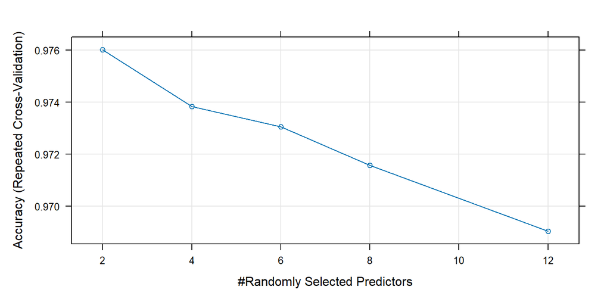

```r
plot(RFModel)
```

```r
# Prediction on test data set using RF model
RFpred=predict(RFModel,newdata = test)

# Evaluate RF model performance metrics
RF_CM<- confusionMatrix(RFpred, as.factor(test$Malaria.Test), positive = "Positive", mode='everything')
M2<- RF_CM$byClass[c(1, 2, 5, 7, 11)]
M2
```

```
      Sensitivity       Specificity         Precision                F1
        0.7837838         0.9789474         0.5918367         0.6744186
Balanced Accuracy
        0.8813656
```

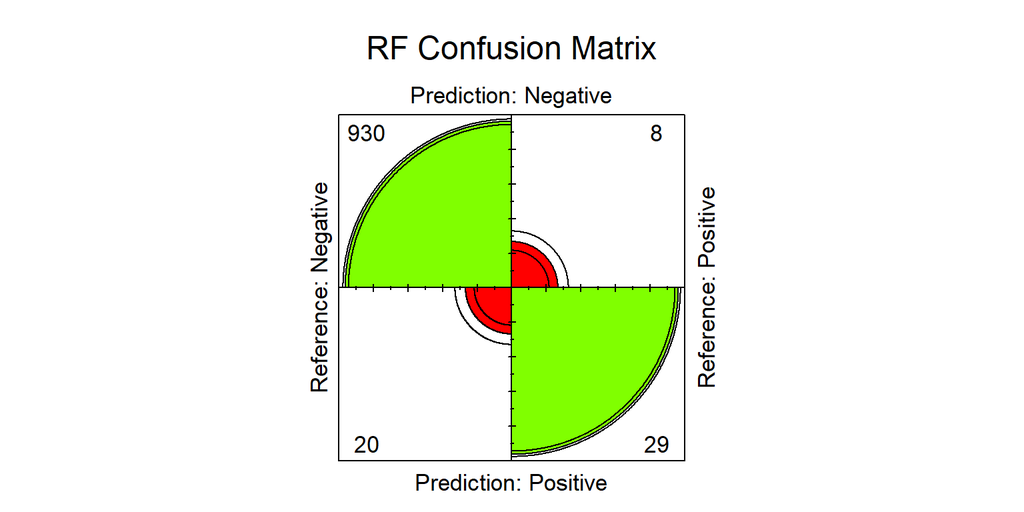

```r
# Ploting Random Forest confusion matrix
fourfoldplot(RF_CM$table, col=rainbow(4), main="RF Confusion Matrix") #RF Confusion Matrix 4fold plot
```

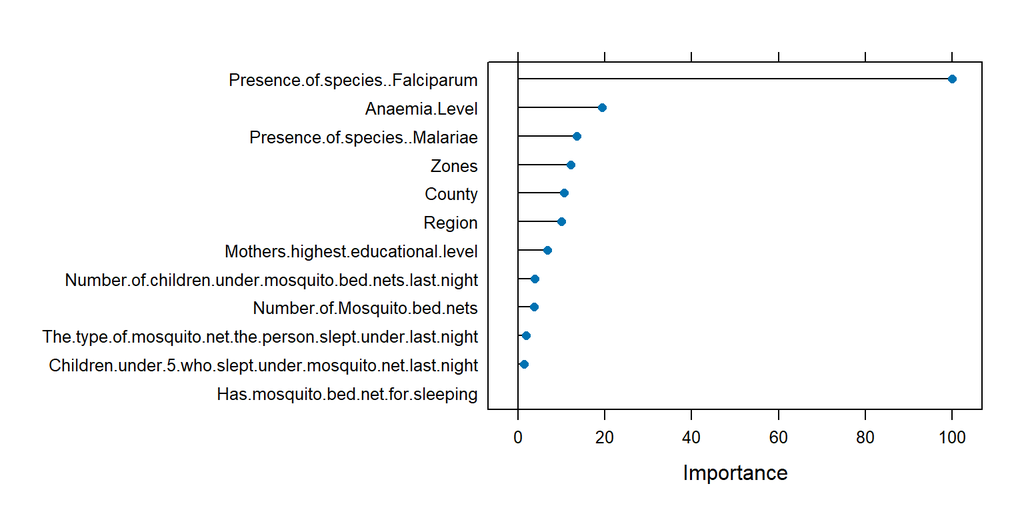

```r
# Show relative importance of features
# Plot using R base function
plot(varImp(RFModel, scale=T))
```

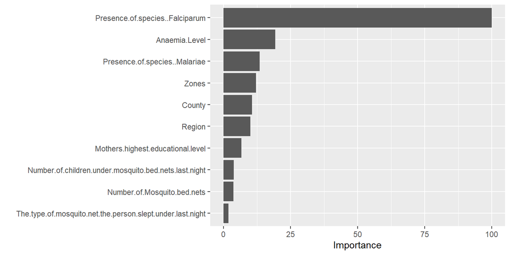

```r
# Alternatively
vip::vip(RFModel)
```

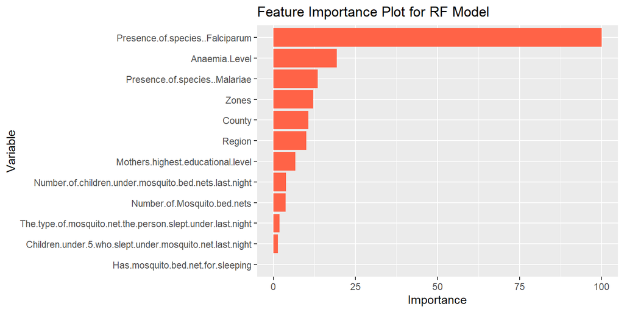

```r
# Alternatively using ggplot function
var_imp <-varImp(RFModel)
ggplot(var_imp, aes(x = reorder(Variable, Importance), y = importance)) +
  geom_bar(stat = "identity", fill = "tomato") +
  coord_flip() +
  xlab("Variable") +
  ylab("Importance") +
  ggtitle("Feature Importance Plot for RF Model")
```

# Create ROC curve for RF model

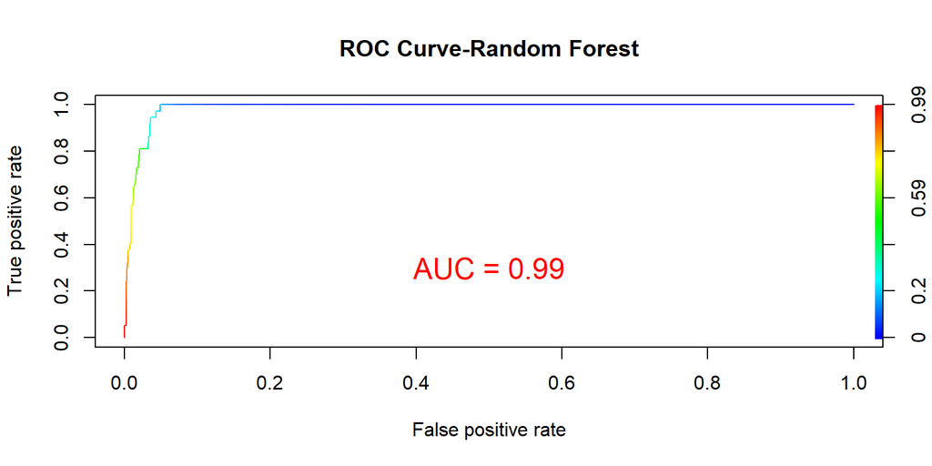

```r
# Make predictions on the test set using type='prob'
predrf <- predict(RFModel, newdata = test, type = "prob")
# Create a prediction object needed by ROCR
pred_rf <- prediction(predrf[, "Positive"], test$Malaria.Test)
# Calculate performance measures like ROC curve
perf_rf <- performance(pred_rf, "tpr", "fpr")
# Plot the ROC curve
plot(perf_rf, colorize = TRUE, main = "ROC Curve-Random Forest")
# Compute AUC
auc_value <- performance(pred_rf, "auc")@y.values[[1]]
auc_label <- paste("AUC =", round(auc_value, 2))
# Add AUC value as text on the plot
text(0.5, 0.3, auc_label, col = "red", cex = 1.5)  # Adjust position
```

# Receiver Operating Characteristic (ROC) Curve

The ROC curve is a graphical representation of the performance of a classification model at all classification thresholds. The curve plots the True Positive Rate (TPR) against the False Positive Rate (FPR).

# True Positive Rate (TPR): Also known as sensitivity or recall,

It is the ratio of correctly predicted positive observations to the actual positives. TPR = TP / (TP + FN), where TP is True Positives and FN is False Negatives.

# False Positive Rate (FPR)

It is the ratio of incorrectly predicted positive observations to the actual negatives. FPR = FP /(FP + TN), where FP is False Positives and TN is True Negatives.

# The AUC is the area under the ROC curve.

It ranges from 0 to 1, with higher values indicating better model performance. AUC = 0.5 suggests no discrimination (i.e., the model is no better than random guessing), AUC = 1.0 indicates perfect discrimination.

AUC = 0.99 is very close to 1.0, suggesting that the model has a high true positive rate and a low false positive rate. This indicates that the Random Forest classifier has an excellent ability to distinguish between the positive and negative classes.

# Train the Decision Tree

```r
tuneGrid_dt <- expand.grid(cp = seq(0.001, 0.1, by = 0.01))
```

```r
set.seed(123)
tic()
DTModel <- train(factor(Malaria.Test)~.,
                 data=train,
                 method="rpart",
                 trControl=control,
                 tuneGrid=tuneGrid_dt)
toc()
```

```
5.79 sec elapsed
```

```r
DTModel
```

```
CART

2293 samples
  12 predictor
   2 classes: 'Negative', 'Positive'

No pre-processing
Resampling: Cross-Validated (10 fold, repeated 5 times)
Summary of sample sizes: 2064, 2063, 2064, 2064, 2064, 2063, ...
Addtional sampling using SMOTE

Resampling results across tuning parameters:

  cp     Accuracy   Kappa
  0.001  0.9695610  0.6654964
  0.011  0.9581347  0.6162524
  0.021  0.9358859  0.5133620
  0.031  0.9358859  0.5133620
  0.041  0.9358859  0.5133620
  0.051  0.9358859  0.5133620
  0.061  0.9358859  0.5133620
  0.071  0.9358859  0.5133620
  0.081  0.9358859  0.5133620
  0.091  0.9358859  0.5133620

Accuracy was used to select the optimal model using the largest value.
The final value used for the model was cp = 0.001.
```

```r
DTModel$results
```

```
      cp  Accuracy     Kappa  AccuracySD    KappaSD
1  0.001 0.9695610 0.6654964 0.008920694 0.09739682
2  0.011 0.9581347 0.6162524 0.012509776 0.09115027
3  0.021 0.9358859 0.5133620 0.012502335 0.06865509
4  0.031 0.9358859 0.5133620 0.012502335 0.06865509
5  0.041 0.9358859 0.5133620 0.012502335 0.06865509
6  0.051 0.9358859 0.5133620 0.012502335 0.06865509
7  0.061 0.9358859 0.5133620 0.012502335 0.06865509
8  0.071 0.9358859 0.5133620 0.012502335 0.06865509
9  0.081 0.9358859 0.5133620 0.012502335 0.06865509
10 0.091 0.9358859 0.5133620 0.012502335 0.06865509
```

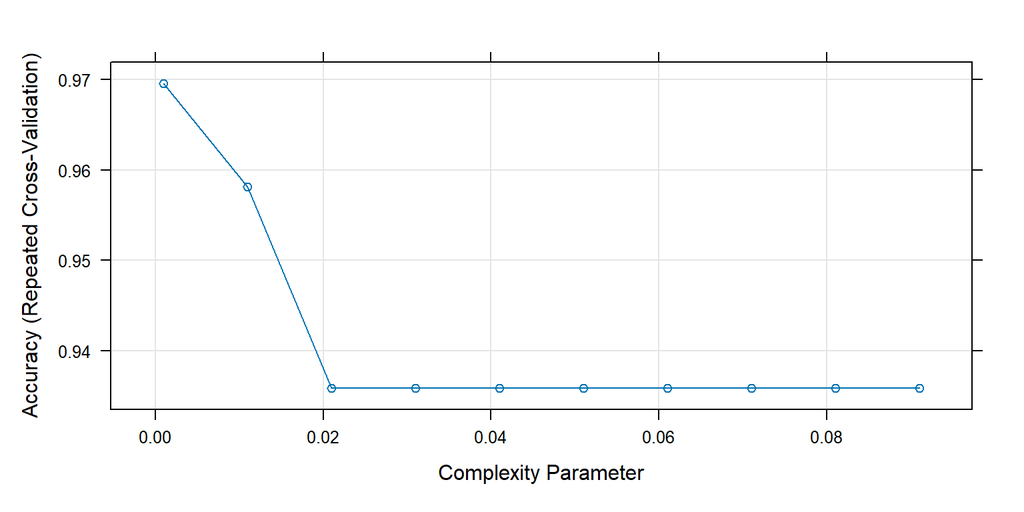

```r
plot(DTModel)
```

```r
## Prediction
DTpred=predict(DTModel,newdata = test)

## Performance Metrics
DT.cM<- confusionMatrix(DTpred,as.factor(test$Malaria.Test), positive = 'Positive', mode='everything')
T2<- DT.cM$byClass[c(1, 2, 5, 7, 11)]
T2
```

```
      Sensitivity       Specificity         Precision                F1
        0.8108108         0.9694737         0.5084746         0.6250000
Balanced Accuracy
        0.8901422
```

```r
## plotting confusion matrix
DT.cM$table
```

```
          Reference
Prediction Negative Positive
  Negative      921        7
  Positive       29       30
```

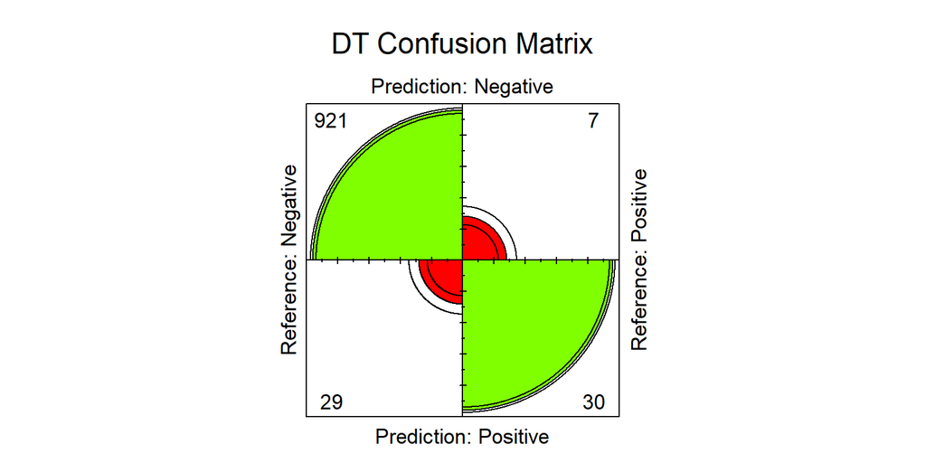

```r
fourfoldplot(DT.cM$table, col=rainbow(4), main="DT Confusion Matrix")
```

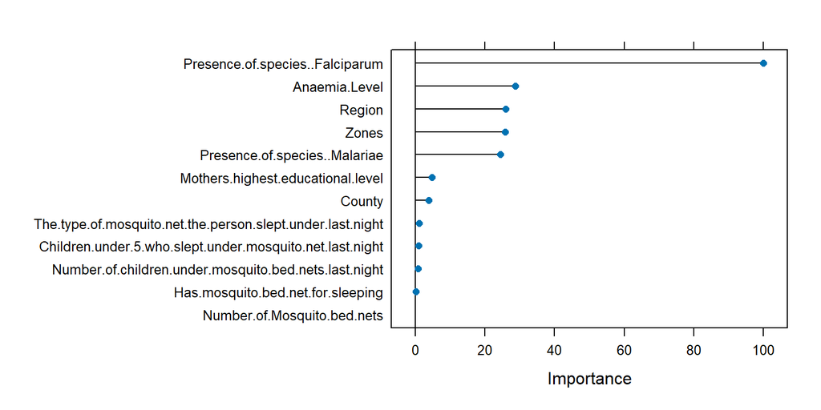

```r
## Plotting the importance features
plot(varImp(DTModel, scale=T))
```

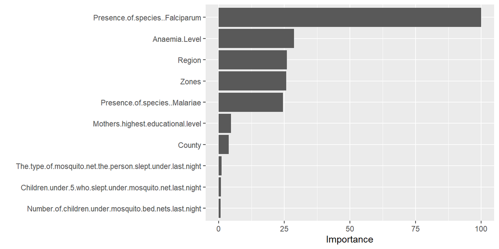

```r
## Plotting the importance features
vip::vip(DTModel)
```

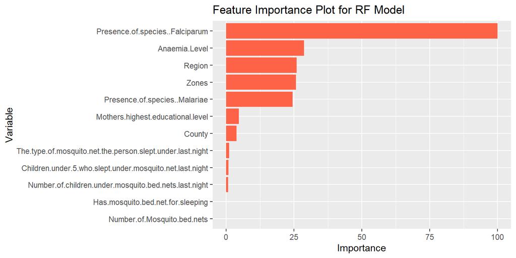

```r
## Alternatively using ggplot function
var_imp <-varImp(DTModel)
ggplot(var_imp, aes(x = reorder(Variable, Importance), y = importance)) +
  geom_bar(stat = "identity", fill = "tomato") +
  coord_flip() +
  xlab("Variable") +
  ylab("Importance") +
  ggtitle("Feature Importance Plot for RF Model")
```

# Create ROC curve for DT model

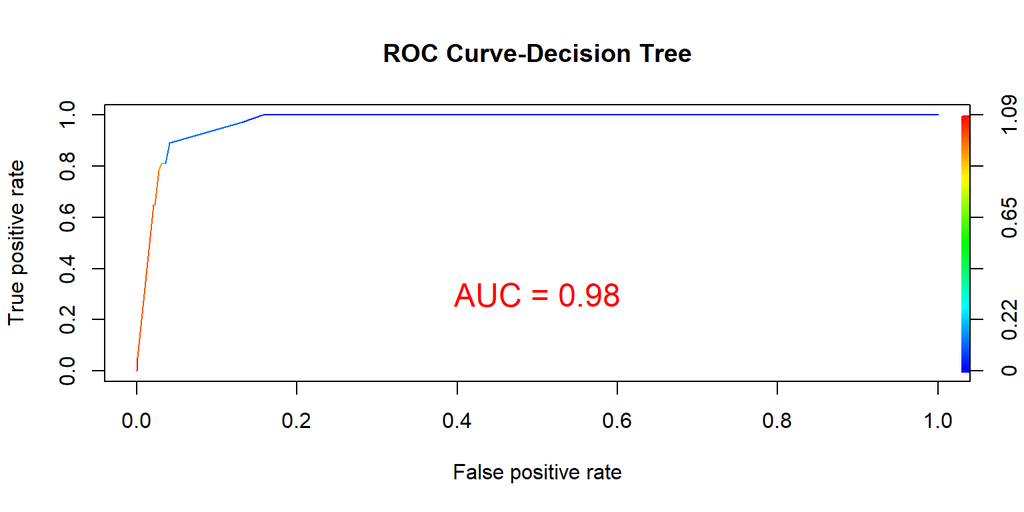

```r
# Make predictions on the test set using type='prob'
predDT <- predict(DTModel, newdata = test, type = "prob")
# Create a prediction object needed by ROCR
pred_DT <- prediction(predDT[, "Positive"], test$Malaria.Test)
# Calculate performance measures like ROC curve
perf_DT <- performance(pred_DT, "tpr", "fpr")
# Plot the ROC curve
plot(perf_DT, colorize = TRUE, main = "ROC Curve-Decision Tree")
# Compute AUC
auc_value <- performance(pred_DT, "auc")@y.values[[1]]
auc_label <- paste("AUC =", round(auc_value, 2))
# Add AUC value as text on the plot
text(0.5, 0.3, auc_label, col = "red", cex = 1.5)  # Adjust position
```

# Train an Logisitic Regression model

```r
set.seed(123)
logRegModel <- train(factor(Malaria.Test)~.,
                     data=train,
                     method="glm",
                     trControl=control,
                     na.action = na.omit)
logRegModel
```

```
Generalized Linear Model

2293 samples
  12 predictor
   2 classes: 'Negative', 'Positive'

No pre-processing
Resampling: Cross-Validated (10 fold, repeated 5 times)
Summary of sample sizes: 2064, 2063, 2064, 2064, 2064, 2063, ...
Addtional sampling using SMOTE

Resampling results:

  Accuracy   Kappa
  0.9410327  0.5323107
```

```r
logRegModel$results
```

```
  parameter  Accuracy     Kappa AccuracySD    KappaSD
1      none 0.9410327 0.5323107 0.01382857 0.07748864
```

```r
# Prediction using trained Logisitic Regression model
logRegpred=predict(logRegModel,newdata = test)

# Evaluation of Logisitic Regression model performance metrics
logReg_CM<- confusionMatrix(logRegpred,as.factor(test$Malaria.Test), positive = 'Positive', mode='everything')
logReg_CM
```

```
Confusion Matrix and Statistics

          Reference
Prediction Negative Positive
  Negative      889        1
  Positive       61       36

               Accuracy : 0.9372
                 95% CI : (0.9202, 0.9515)
    No Information Rate : 0.9625
    P-Value [Acc > NIR] : 1

                  Kappa : 0.5108

 Mcnemar's Test P-Value : 6.731e-14

            Sensitivity : 0.97297
            Specificity : 0.93579
         Pos Pred Value : 0.37113
         Neg Pred Value : 0.99888
              Precision : 0.37113
                 Recall : 0.97297
                     F1 : 0.53731
             Prevalence : 0.03749
         Detection Rate : 0.03647
   Detection Prevalence : 0.09828
      Balanced Accuracy : 0.95438

       'Positive' Class : Positive
```

```r
M3<- logReg_CM$byClass[c(1, 2, 5, 7, 11)]
M3
```

```
      Sensitivity       Specificity         Precision                F1
        0.9729730         0.9357895         0.3711340         0.5373134
Balanced Accuracy
        0.9543812
```

```r
#plotting confusion matrix
logReg_CM$table
```

```
          Reference
Prediction Negative Positive
  Negative      889        1
  Positive       61       36
```

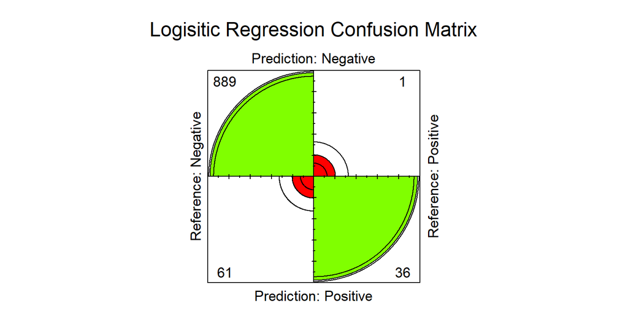

```r
fourfoldplot(logReg_CM$table, col=rainbow(4), main="Logisitic Regression Confusion Matrix")
```

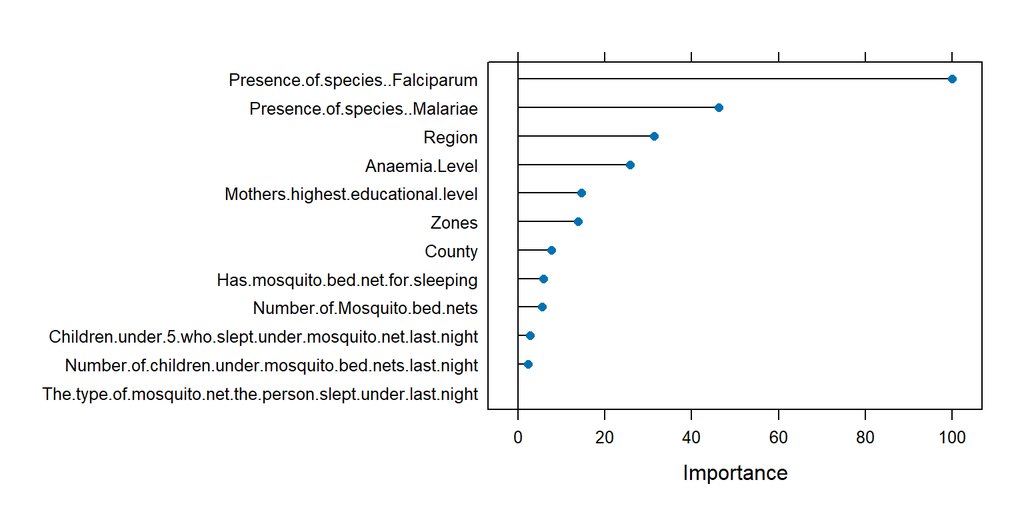

```r
## Plotting the importance features
plot(varImp(logRegModel, scale=T))
```

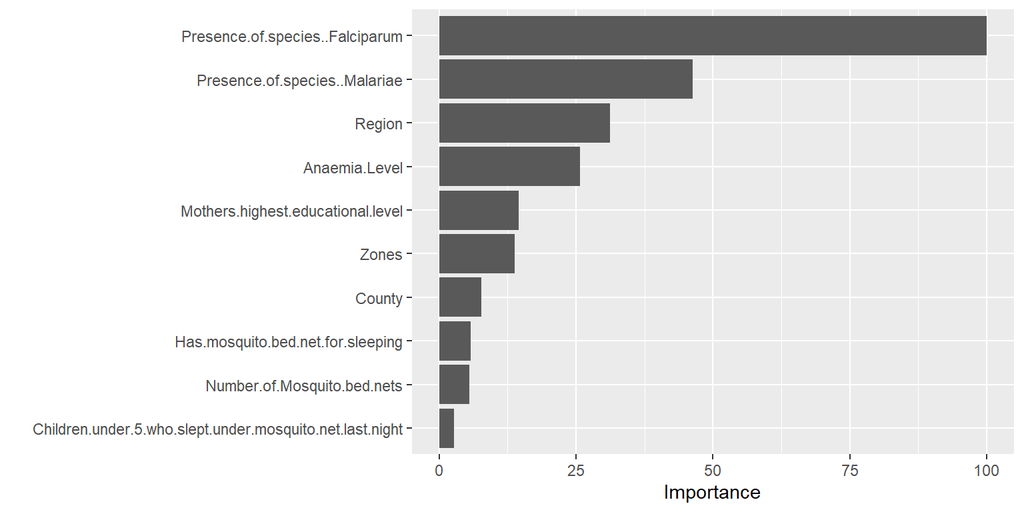

```r
## Plotting the importance features
vip::vip(logRegModel)
```

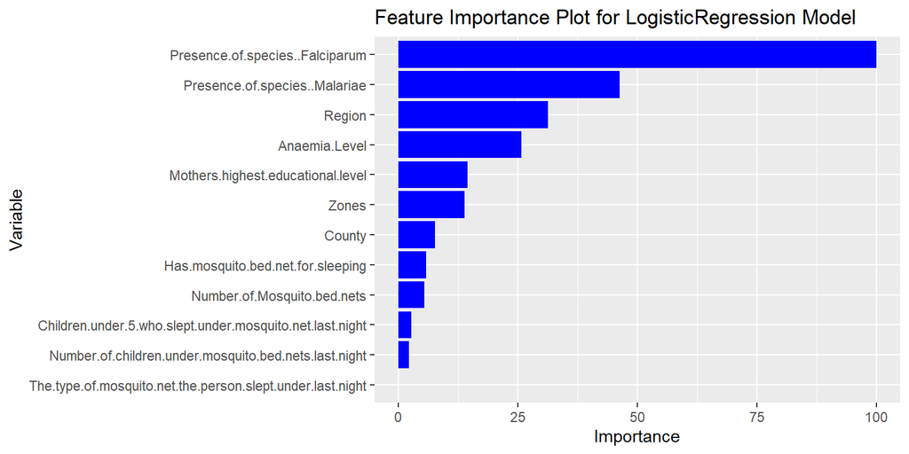

```r
# Alternatively using ggplot function
varImp <-varImp(logRegModel)
ggplot(varImp, aes(x = reorder(Variable, Importance), y = importance)) +
  geom_bar(stat = "identity", fill = "blue") +
  coord_flip() +
  xlab("Variable") +
  ylab("Importance") +
  ggtitle("Feature Importance Plot for LogisticRegression Model")
```

# Prediction using trained Logisitic Regression model

```r
logRegpred=predict(logRegModel,newdata = test)

logRegPredProb <- predict(logRegModel, newdata = test, type ="prob")*100

# Combine data into a data frame
Ground_truth<- test$Malaria.Test
Predicted <- logRegpred

resultLR <- data.frame(Ground_truth, Predicted)
resultLR$Correct <- resultLR$Ground_truth == resultLR$Predicted

# Add a column for classification results (correct/incorrect)
resultLogreg<- data.frame(test, logRegpred, resultLR$Correct)
#head(resultLogreg)
head(resultLR)
```

```
  Ground_truth Predicted Correct
1     Negative  Negative    TRUE
2     Negative  Negative    TRUE
3     Negative  Negative    TRUE
4     Negative  Negative    TRUE
5     Negative  Negative    TRUE
6     Negative  Negative    TRUE
```

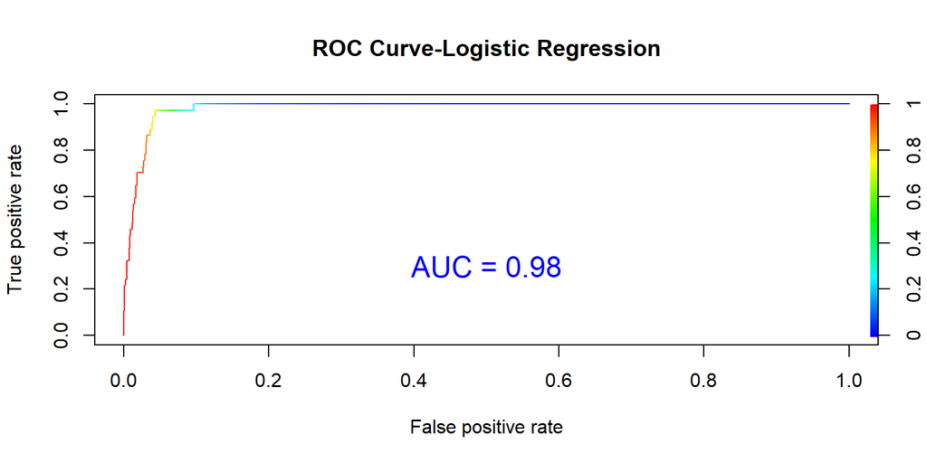

```r
# Make predictions on the test set using type='prob'
predlogReg <- predict(logRegModel, newdata = test, type = "prob")
# Create a prediction object needed by ROCR
pred_logReg <- prediction(predlogReg[, "Positive"], test$Malaria.Test)
# Calculate performance measures like ROC curve
perf_logReg <- performance(pred_logReg, "tpr", "fpr")
# Plot the ROC curve
plot(perf_logReg, colorize = TRUE, main = "ROC Curve-Logistic Regression")
# Compute AUC
auc_value <- performance(pred_logReg, "auc")@y.values[[1]]
auc_label <- paste("AUC =", round(auc_value, 2))
# Add AUC value as text on the plot
text(0.5, 0.3, auc_label, col = "blue", cex = 1.5)  # Adjust position and other text parameters as needed
```

# Train a k- Nearest Neigbour Model

#k-Nearest Neighbors (k-NN) k-NN is a simple, non-parametric, and lazy learning algorithm used for both classification and regression tasks.

# k

```r
tuneGrid_knn <- expand.grid(k = seq(1, 20, 2))
```

```r
set.seed(123)
knnModel <- train(factor(Malaria.Test)~.,
                  data = train,
                  method ="knn",
                  tuneGrid = tuneGrid_knn,
                  trControl = control)
knnModel
```

```
k-Nearest Neighbors

2293 samples
  12 predictor
   2 classes: 'Negative', 'Positive'

No pre-processing
Resampling: Cross-Validated (10 fold, repeated 5 times)
Summary of sample sizes: 2064, 2063, 2064, 2064, 2064, 2063, ...
Addtional sampling using SMOTE

Resampling results across tuning parameters:

  k   Accuracy   Kappa
   1  0.9517763  0.4160639
   3  0.9386067  0.3958401
   5  0.9339877  0.4200521
   7  0.9303169  0.4232487
   9  0.9161901  0.3832620
  11  0.9052051  0.3577896
  13  0.8969195  0.3397336
  15  0.8902041  0.3324315
  17  0.8846282  0.3220709
  19  0.8781748  0.3090380

Accuracy was used to select the optimal model using the largest value.
The final value used for the model was k = 1.
```

```r
knnModel$results
```

```
    k  Accuracy     Kappa AccuracySD    KappaSD
1   1 0.9517763 0.4160639 0.01224871 0.14478534
2   3 0.9386067 0.3958401 0.01345898 0.11410523
3   5 0.9339877 0.4200521 0.01621014 0.10549410
4   7 0.9303169 0.4232487 0.01521229 0.09671628
5   9 0.9161901 0.3832620 0.01899379 0.09292577
6  11 0.9052051 0.3577896 0.02071000 0.08126019
7  13 0.8969195 0.3397336 0.02008379 0.08238670
8  15 0.8902041 0.3324315 0.02175142 0.07793744
9  17 0.8846282 0.3220709 0.02058462 0.06780595
10 19 0.8781748 0.3090380 0.02220743 0.06551074
```

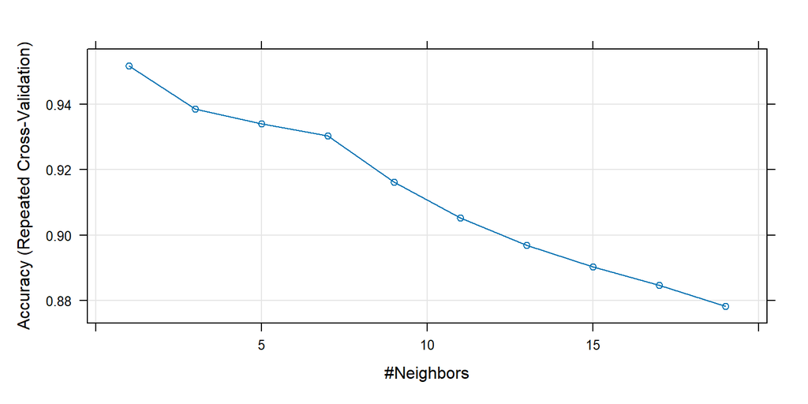

```r
plot(knnModel)
```

```r
# Prediction using knnModel
knnpred = predict(knnModel,newdata = test)

# Evaluation of model performance metrics
knn_CM<- confusionMatrix(knnpred,as.factor(test$Malaria.Test), positive = 'Positive', mode='everything')
M4<- knn_CM$byClass [c(1, 2, 5, 7, 11)]
M4
```

```
      Sensitivity       Specificity         Precision                F1
        0.6756757         0.9800000         0.5681818         0.6172840
Balanced Accuracy
        0.8278378
```

```r
#plotting confusion matrix
knn_CM$table
```

```
          Reference
Prediction Negative Positive
  Negative      931       12
  Positive       19       25
```

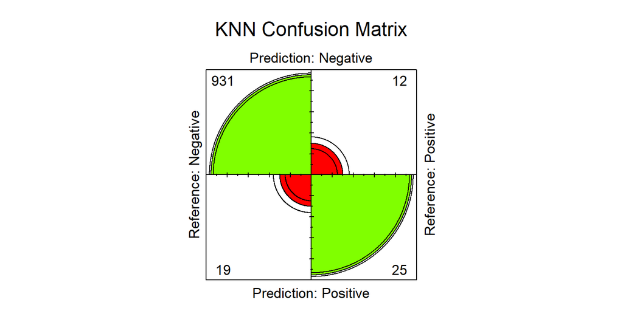

```r
fourfoldplot(knn_CM$table, col=rainbow(4), main="KNN Confusion Matrix")
```

```r
# Show relative importance of features
# Plot using R base function
plot(varImp(knnModel, scale=T))
```

[output not shown]

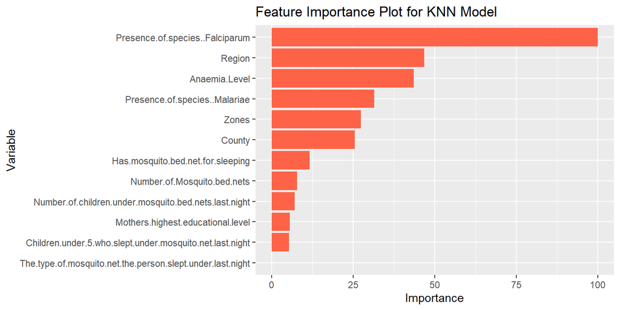

```r
# Alternatively using ggplot function
var_imp <-varImp(knnModel)
ggplot(var_imp, aes(x = reorder(Variable, Importance), y = importance)) +
  geom_bar(stat = "identity", fill = "tomato") +
  coord_flip() +
  xlab("Variable") +
  ylab("Importance") +
  ggtitle("Feature Importance Plot for KNN Model")
```

# Create ROC curve for DT model

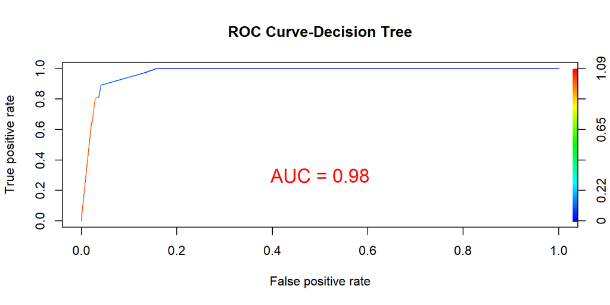

```r
# Make predictions on the test set using type='prob'
predDT <- predict(DTModel, newdata = test, type = "prob")
# Create a prediction object needed by ROCR
pred_DT <- prediction(predDT[, "Positive"], test$Malaria.Test)
# Calculate performance measures like ROC curve
perf_DT <- performance(pred_DT, "tpr", "fpr")
# Plot the ROC curve
plot(perf_DT, colorize = TRUE, main = "ROC Curve-Decision Tree")
# Compute AUC
auc_value <- performance(pred_DT, "auc")@y.values[[1]]
auc_label <- paste("AUC =", round(auc_value, 2))
# Add AUC value as text on the plot
text(0.5, 0.3, auc_label, col = "red", cex = 1.5)  # Adjust position
```

# Train a Neural Net model

# Neural Network (NN)

```r
#set.seed(123)
#tic()
#nnModel <- train(factor(Malaria.Test)~., data=train, method="nnet", trControl=control)
#toc()
#nnModel
#nnpred=predict(nnModel,newdata = test)
#nn_CM<- confusionMatrix(nnpred,as.factor(test$Malaria.Test), positive = 'Positive', #mode='everything')
#M5<- nn_CM$byClass[c(1, 2, 5, 7, 11)]
#M5
#plotting confusion matrix
#nn_CM$table
#fourfoldplot(nn_CM$table, col=rainbow(4), main="Neural Network Confusion Matrix")
#plot(varImp(nnModel, scale=T))
```

```r
#library(NeuralNetTools)
#plotnet(nnModel$finalModel)
```

## Components of the Neural Network:

### Output Layer (O1):

The output layer has one node, labeled O1, which represents the predicted output of the model. In this binary classification problem, the output might be the probability of having severe malaria.

### Bias Nodes (B1, B2):

Bias nodes B1 and B2 provide an additional parameter to the model, helping it better fit the data. B1 is connected to the hidden layer, and B2 is connected to the output layer.

## Explanation of the Network Functioning:

### Input to Hidden Layer:

Each input feature is multiplied by its corresponding weight and passed to the hidden node H1. The hidden node H1 sums these weighted inputs along with the bias B1.

### Hidden Layer Activation:

The hidden node H1 applies an activation function (commonly a nonlinear function like sigmoid or ReLU) to the summed inputs to introduce nonlinearity into the model.

### Hidden to Output Layer:

The activated output of H1 is multiplied by the weight of the connection to the output node O1 and passed to O1. Similarly, the bias B2 is also added to the output node O1.

### Output Layer Activation:

The output node O1 might apply another activation function to produce the final prediction, such as a probability score in the case of binary classification.

# Train a Naive Bayes model

```r
tuneGrid_nb <- expand.grid(fL = c(0, 0.5, 1),
                           usekernel = c(TRUE, FALSE),
                           adjust = c(0, 0.5, 1))
```

```r
set.seed(123)
NBModel <- train(factor(Malaria.Test)~.,
                 data=train,
                 method="nb",
                 tuneGrid=tuneGrid_nb,
                 trControl=control)
NBModel
```

```
Naive Bayes

2293 samples
  12 predictor
   2 classes: 'Negative', 'Positive'

No pre-processing
Resampling: Cross-Validated (10 fold, repeated 5 times)
Summary of sample sizes: 2064, 2063, 2064, 2064, 2064, 2063, ...
Addtional sampling using SMOTE

Resampling results across tuning parameters:

  fL   usekernel  adjust  Accuracy   Kappa
  0.0  FALSE      0.0     0.9539441  0.5889057
  0.0  FALSE      0.5     0.9536817  0.5850026
  0.0  FALSE      1.0     0.9533327  0.5838523
  0.0   TRUE      0.0           NaN        NaN
  0.0   TRUE      0.5     0.7912005  0.2188089
  0.0   TRUE      1.0     0.7425290  0.1797532
  0.5  FALSE      0.0     0.9531580  0.5817336
  0.5  FALSE      0.5     0.9535955  0.5853284
  0.5  FALSE      1.0     0.9542926  0.5894496
  0.5   TRUE      0.0           NaN        NaN
  0.5   TRUE      0.5     0.7907581  0.2187021
  0.5   TRUE      1.0     0.7447064  0.1807587
  1.0  FALSE      0.0     0.9528960  0.5821567
  1.0  FALSE      0.5     0.9539444  0.5869387
  1.0  FALSE      1.0     0.9536824  0.5863806
  1.0   TRUE      0.0           NaN        NaN
  1.0   TRUE      0.5     0.7949575  0.2242800
  1.0   TRUE      1.0     0.7461125  0.1816770

Accuracy was used to select the optimal model using the largest value.
The final values used for the model were fL = 0.5, usekernel = FALSE and
 adjust = 1.
```

```r
NBModel$results
```

```
    fL usekernel adjust  Accuracy     Kappa AccuracySD    KappaSD
1  0.0     FALSE    0.0 0.9539441 0.5889057 0.01156672 0.08212105
2  0.0     FALSE    0.5 0.9536817 0.5850026 0.01097882 0.08374248
3  0.0     FALSE    1.0 0.9533327 0.5838523 0.01127522 0.08226793
4  0.0      TRUE    0.0       NaN       NaN         NA         NA
5  0.0      TRUE    0.5 0.7912005 0.2188089 0.04337927 0.05012080
6  0.0      TRUE    1.0 0.7425290 0.1797532 0.04193265 0.03634353
7  0.5     FALSE    0.0 0.9531580 0.5817336 0.01132925 0.08269847
8  0.5     FALSE    0.5 0.9535955 0.5853284 0.01142542 0.08353481
9  0.5     FALSE    1.0 0.9542926 0.5894496 0.01055701 0.08264921
10 0.5      TRUE    0.0       NaN       NaN         NA         NA
11 0.5      TRUE    0.5 0.7907581 0.2187021 0.04490693 0.04944998
12 0.5      TRUE    1.0 0.7447064 0.1807587 0.04050720 0.03535167
13 1.0     FALSE    0.0 0.9528960 0.5821567 0.01187309 0.08655811
14 1.0     FALSE    0.5 0.9539444 0.5869387 0.01094986 0.08294439
15 1.0     FALSE    1.0 0.9536824 0.5863806 0.01132587 0.08468644
16 1.0      TRUE    0.0       NaN       NaN         NA         NA
17 1.0      TRUE    0.5 0.7949575 0.2242800 0.04375849 0.05297107
18 1.0      TRUE    1.0 0.7461125 0.1816770 0.04429947 0.03815542
```

```r
NBModel$bestTune
```

```
   fL usekernel adjust
9 0.5     FALSE      1
```

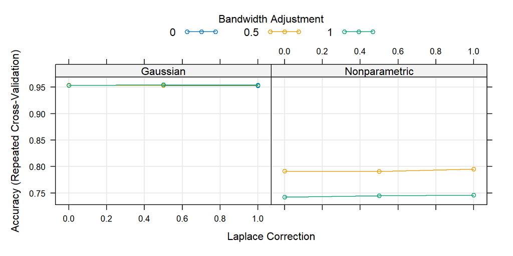

```r
plot(NBModel)
```

```r
# Prediction using Model
NBpred=predict(NBModel,newdata = test)

# Evaluation of model performance metrics
NB_CM<- confusionMatrix(NBpred,as.factor(test$Malaria.Test), positive = 'Positive', mode='everything')
M6<- NB_CM$byClass[c(1, 2, 5, 7, 11)]
M6
```

```
      Sensitivity       Specificity         Precision                F1
        0.9189189         0.9494737         0.4146341         0.5714286
Balanced Accuracy
        0.9341963
```

```r
#plotting confusion matrix
NB_CM$table
```

```
          Reference
Prediction Negative Positive
  Negative      902        3
  Positive       48       34
```

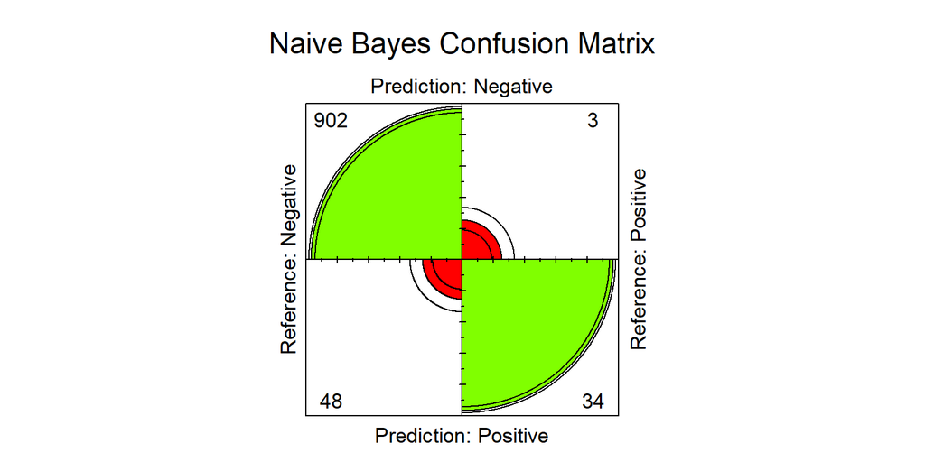

```r
fourfoldplot(NB_CM$table, col=rainbow(4), main="Naive Bayes Confusion Matrix")
```

```r
# Show relative importance of features
# Plot using R base function
plot(varImp(NBModel, scale=T))
```

[output not shown]

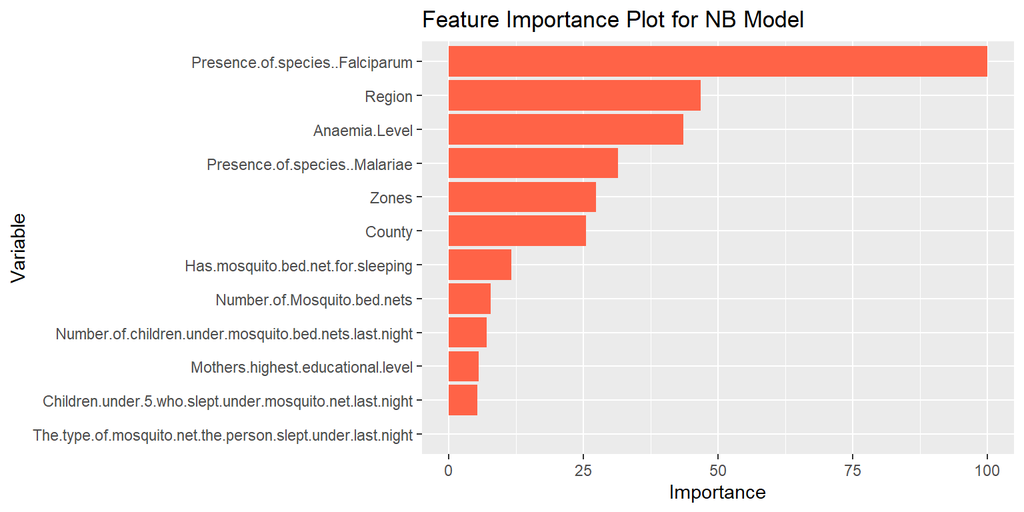

```r
# Alternatively using ggplot function
var_imp <-varImp(NBModel)
ggplot(var_imp, aes(x = reorder(Variable, Importance), y = importance)) +
  geom_bar(stat = "identity", fill = "tomato") +
  coord_flip() +
  xlab("Variable") +
  ylab("Importance") +
  ggtitle("Feature Importance Plot for NB Model")
```

# Create ROC curve for NB model

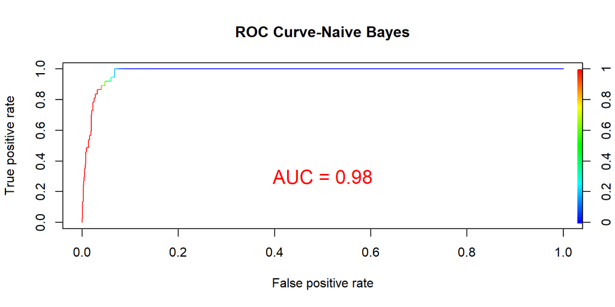

```r
# Make predictions on the test set using type='prob'
predNB <- predict(NBModel, newdata = test, type = "prob")
# Create a prediction object needed by ROCR
pred_NB <- prediction(predNB[, "Positive"], test$Malaria.Test)
# Calculate performance measures like ROC curve
perf_NB <- performance(pred_NB, "tpr", "fpr")
# Plot the ROC curve
plot(perf_NB, colorize = TRUE, main = "ROC Curve-Naive Bayes")
# Compute AUC
auc_value <- performance(pred_NB, "auc")@y.values[[1]]
auc_label <- paste("AUC =", round(auc_value, 2))
# Add AUC value as text on the plot
text(0.5, 0.3, auc_label, col = "red", cex = 1.5)  # Adjust position
```

## Train a Linear Discriminant Analysis model

```r
set.seed(123)
LDAModel <- train(factor(Malaria.Test)~., data=train, method="lda", trControl=control)
LDAModel
```

```
Linear Discriminant Analysis

2293 samples
  12 predictor
   2 classes: 'Negative', 'Positive'

No pre-processing
Resampling: Cross-Validated (10 fold, repeated 5 times)
Summary of sample sizes: 2064, 2063, 2064, 2064, 2064, 2063, ...
Addtional sampling using SMOTE

Resampling results:

  Accuracy   Kappa
  0.9358859  0.513362
```

```r
LDAModel$results
```

```
  parameter  Accuracy    Kappa AccuracySD    KappaSD
1      none 0.9358859 0.513362 0.01250233 0.06865509
```

```r
# Prediction using Model
LDApred=predict(LDAModel,newdata = test)

# Evaluation of model performance metrics
LDA_CM<- confusionMatrix(LDApred,as.factor(test$Malaria.Test), positive = 'Positive', mode='everything')
M7<- LDA_CM$byClass[c(1, 2, 5, 7, 11)]
M7
```

```
      Sensitivity       Specificity         Precision                F1
        0.9189189         0.9294737         0.3366337         0.4927536
Balanced Accuracy
        0.9241963
```

```r
#plotting confusion matrix
LDA_CM$table
```

```
          Reference
Prediction Negative Positive
  Negative      883        3
  Positive       67       34
```

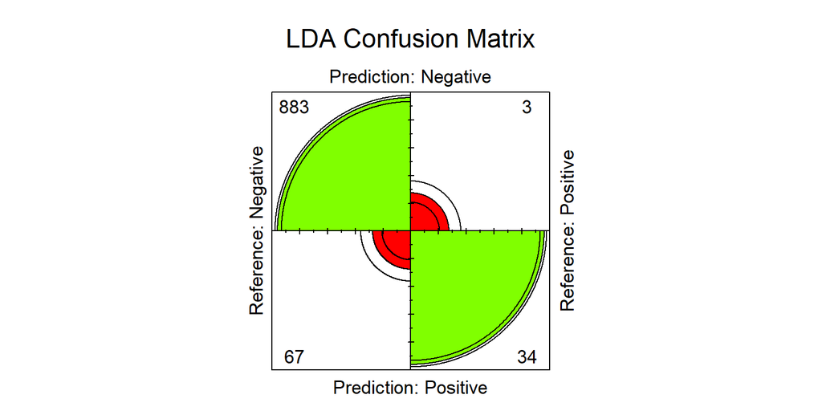

```r
fourfoldplot(LDA_CM$table, col=rainbow(4), main="LDA Confusion Matrix")
```

```r
# Show relative importance of features
# Plot using R base function
plot(varImp(LDAModel, scale=T))
```

[output not shown]

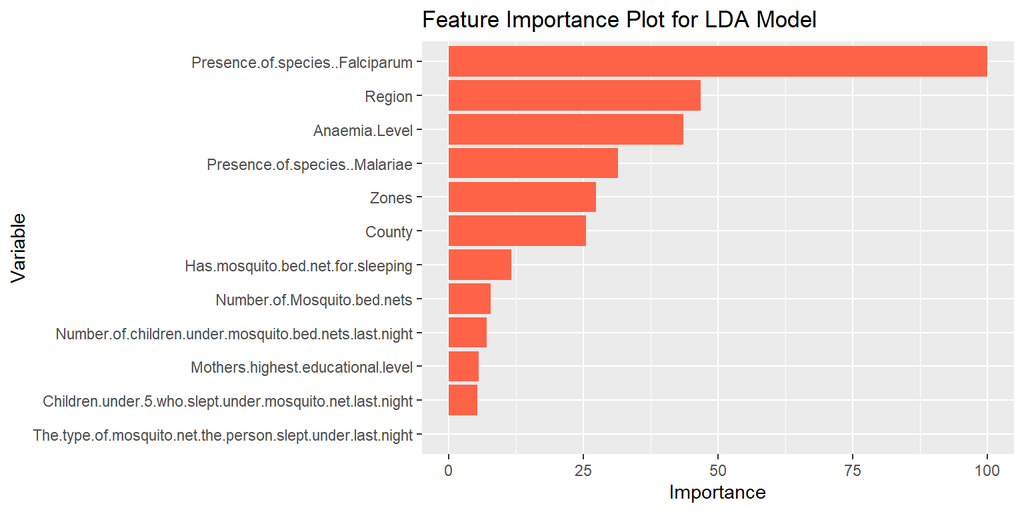

```r
# Alternatively using ggplot function
var_imp <-varImp(LDAModel)
ggplot(var_imp, aes(x = reorder(Variable, Importance), y = importance)) +
  geom_bar(stat = "identity", fill = "tomato") +
  coord_flip() +
  xlab("Variable") +
  ylab("Importance") +
  ggtitle("Feature Importance Plot for LDA Model")
```

# Create ROC curve for LDA model

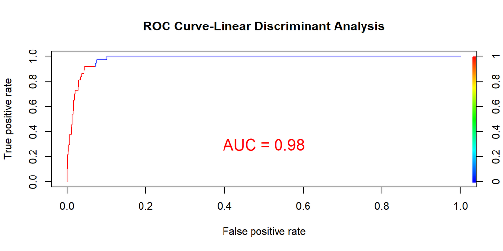

```r
# Make predictions on the test set using type='prob'
predLDA <- predict(LDAModel, newdata = test, type = "prob")
# Create a prediction object needed by ROCR
pred_LDA <- prediction(predLDA[, "Positive"], test$Malaria.Test)
# Calculate performance measures like ROC curve
perf_LDA <- performance(pred_LDA, "tpr", "fpr")
# Plot the ROC curve
plot(perf_LDA, colorize = TRUE, main = "ROC Curve-Linear Discriminant Analysis")
# Compute AUC
auc_value <- performance(pred_LDA, "auc")@y.values[[1]]
auc_label <- paste("AUC =", round(auc_value, 2))
# Add AUC value as text on the plot
text(0.5, 0.3, auc_label, col = "red", cex = 1.5)  # Adjust position
```

# Train a Learning Vector Quantization model

```r
tuneGrid_lvq <- expand.grid(size = c(5, 10, 15),
                            k = c(1, 3, 5),
                            learning_rate = c(0.01, 0.05, 0.1))
```

```r
set.seed(123)
LVQModel <- train(factor(Malaria.Test)~.,
                  data=train,
                  method="lvq",
                  #tuneGrid=tuneGrid_lvq,
                  trControl=control)
LVQModel
```

```
Learning Vector Quantization

2293 samples
  12 predictor
   2 classes: 'Negative', 'Positive'

No pre-processing
Resampling: Cross-Validated (10 fold, repeated 5 times)
Summary of sample sizes: 2064, 2063, 2064, 2064, 2064, 2063, ...
Addtional sampling using SMOTE

Resampling results across tuning parameters:

  size  k   Accuracy   Kappa
   6     1  0.5491311  0.05319595
   6     6  0.5418788  0.03900416
   6    11  0.5542015  0.04202474
   9     1  0.5812883  0.05903080
   9     6  0.5287144  0.04530489
   9    11  0.5399505  0.05687950
  12     1  0.6273217  0.08744450
  12     6  0.6000053  0.07401649
  12    11  0.6188982  0.06904434

Accuracy was used to select the optimal model using the largest value.
The final values used for the model were size = 12 and k = 1.
```

```r
LVQModel$results
```

```
  size  k  Accuracy      Kappa AccuracySD    KappaSD
1    6  1 0.5491311 0.05319595  0.1422524 0.04368981
2    6  6 0.5418788 0.03900416  0.1713943 0.04615479
3    6 11 0.5542015 0.04202474  0.1487872 0.04504135
4    9  1 0.5812883 0.05903080  0.1046262 0.04605551
5    9  6 0.5287144 0.04530489  0.1365722 0.03943479
6    9 11 0.5399505 0.05687950  0.1181490 0.03266698
7   12  1 0.6273217 0.08744450  0.1118297 0.04656601
8   12  6 0.6000053 0.07401649  0.1142337 0.03939379
9   12 11 0.6188982 0.06904434  0.1041721 0.04596663
```

```r
# Prediction using Model
LVQpred=predict(LVQModel,newdata = test)

# Evaluation of model performance metrics
LVQ_CM<- confusionMatrix(LVQpred,as.factor(test$Malaria.Test), positive = 'Positive', mode='everything')
M8<- LVQ_CM$byClass[c(1, 2, 5, 7, 11)]
M8
```

```
      Sensitivity       Specificity         Precision                F1
       0.81081081        0.69052632        0.09259259        0.16620499
Balanced Accuracy
       0.75066856
```

```r
#plotting confusion matrix
LVQ_CM$table
```

```
          Reference
Prediction Negative Positive
  Negative      656        7
  Positive      294       30
```

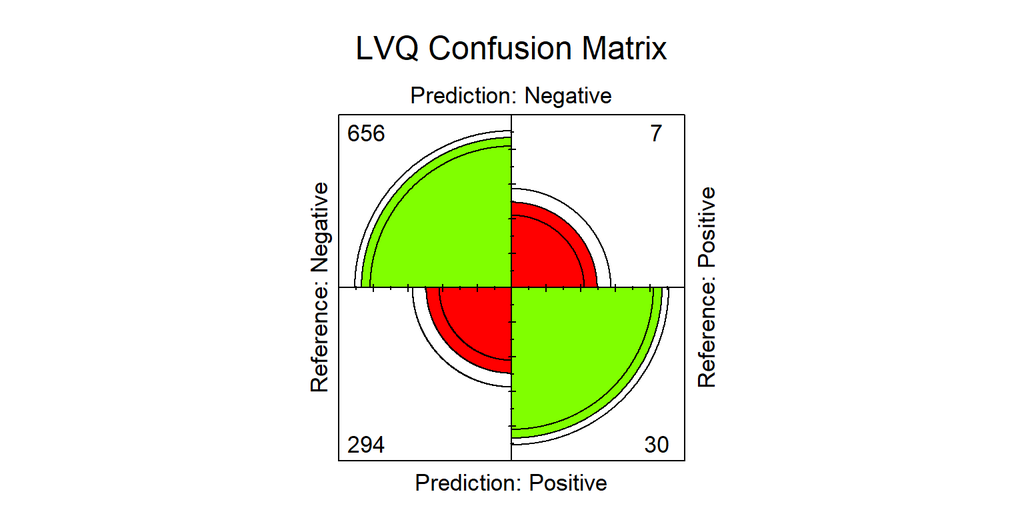

```r
fourfoldplot(LVQ_CM$table, col=rainbow(4), main="LVQ Confusion Matrix")
```

```r
# Show relative importance of features
# Plot using R base function
plot(varImp(LVQModel, scale=T))
```

[output not shown]

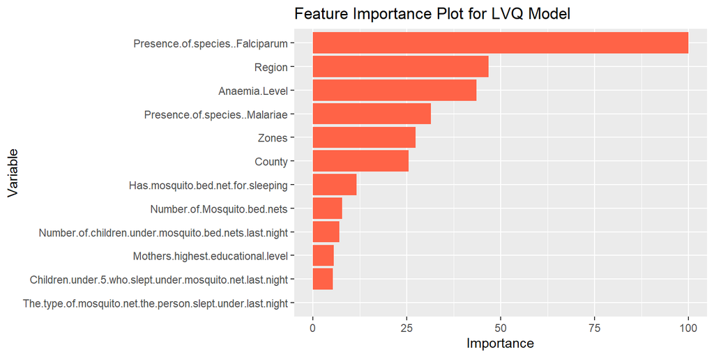

```r
# Alternatively using ggplot function
var_imp <-varImp(LVQModel)
ggplot(var_imp, aes(x = reorder(Variable, Importance), y = importance)) +
  geom_bar(stat = "identity", fill = "tomato") +
  coord_flip() +
  xlab("Variable") +
  ylab("Importance") +
  ggtitle("Feature Importance Plot for LVQ Model")
```